# Beach Volleyball

### An Analysis of Olympic Beach Volleyball and Factors Linked to Player and Team Success

[figure not shown]

#### By: Katherine Krause, Caroline Tobin, Garrett Gerdau, Disha Gopal, and Tanay Singhal

##### Introduction

For this project, our group chose to analyze beach volleyball: a fast-paced, dynamic sport that was fairly recently added to Olympic competition in 1996. In beach volleyball, there are two teams of two players on a sand court with a net in the middle. The goal for each team for each point is to ground the ball on the opponent’s side of the net. Each team is allowed up to three touches to return the ball over the net and no player can touch the ball twice consecutively unless following a blocking shot. Each point starts with a serve and ends when there is a fault, the ball goes out of bounds, or the ball is grounded. The team that wins the rally serves the following point and the four players serve in the same sequence for the duration of the match, switching servers each time a point is won by the receiving team. Additionally, the sport of beach volleyball is a series of best of three sets. The first two sets are played until one team reaches 21 points by two points. The third set, if needed, is played until one team reaches 15 points by two points.

As beach volleyball was fairly recently introduced to the global stage of competition and we could find very limited public statistics on the sport, we decided that analysis of some of its key variables could provide value. We hypothesized that serving or receiving status plays a significant role in point conversion. Additionally, we predicted that the number of touches could prove to be an important variable in points won. We also were interested in finding a way to measure teamwork, which we viewed as essential in a partner-oriented sport like beach volleyball. In order to test these predictions, we compiled data focusing on 14 statistical variables through analyzing Olympic volleyball matches and a preview of this data can be seen below.

#### Play-By-Play Dataset

| Gender | Point | Set | Name | Touches…WT | Touches…LT | Ace | Dives..WT | Spikes.WT | Blocks…WT | Dives…LT | Spikes…LT | Blocks…LT |
| --- | --- | --- | --- | --- | --- | --- | --- | --- | --- | --- | --- | --- |
| M | 1 | 1 | Krasilnikov | 0 | 3 | N | 0 | 0 | 0 | 0 | 1 | 0 |
| M | 2 | 1 | Stoyanovskiy | 5 | 3 | N | 0 | 0 | 0 | 1 | 1 | 0 |
| M | 3 | 1 | Krasilnikov | 1 | 0 | Y | 0 | 0 | 0 | 0 | 0 | 0 |
| M | 4 | 1 | Mol | 3 | 0 | N | 0 | 1 | 0 | 0 | 0 | 0 |
| M | 5 | 1 | Krasilnikov | 1 | 3 | N | 0 | 0 | 0 | 0 | 1 | 0 |
| F | 1 | 2 | Ross | 3 | 4 | N | 1 | 0 | 0 | 0 | 0 | 1 |
| F | 2 | 2 | May | 3 | 0 | N | 0 | 1 | 0 | 0 | 0 | 0 |
| F | 3 | 2 | Kessy | 0 | 3 | N | 0 | 0 | 0 | 1 | 1 | 1 |
| F | 4 | 2 | May | 3 | 0 | N | 0 | 1 | 0 | 0 | 0 | 0 |
| F | 5 | 2 | May | 3 | 4 | N | 1 | 1 | 0 | 0 | 0 | 0 |

#### Table 1: Numerical Variable Summary (Play-By-Play)

| Statistic | Min | Q1 | Median | Q3 | Max | Mean | SD |
| --- | --- | --- | --- | --- | --- | --- | --- |
| Touches - WT | 0 | 0 | 2 | 3 | 9 | 1.98 | 1.84 |
| Touches - LT | 0 | 0 | 2 | 3 | 6 | 2.05 | 1.69 |
| Dives - WT | 0 | 0 | 0 | 0 | 2 | 0.16 | 0.38 |
| Dives - LT | 0 | 0 | 0 | 0 | 2 | 0.14 | 0.39 |
| Spikes - WT | 0 | 0 | 0 | 1 | 2 | 0.47 | 0.58 |
| Spikes - LT | 0 | 0 | 0 | 1 | 3 | 0.47 | 0.61 |
| Blocks - WT | 0 | 0 | 0 | 0 | 2 | 0.09 | 0.31 |
| Blocks - LT | 0 | 0 | 0 | 0 | 2 | 0.09 | 0.30 |

#### Table 1b: Numerical Variable Summary (Set)

| Statistic | Min | Q1 | Median | Q3 | Max | Mean | SD |
| --- | --- | --- | --- | --- | --- | --- | --- |
| Points.Scored | 11 | 15.00 | 19.0 | 21.00 | 23 | 17.890 | 3.6301250 |
| Blocks | 0 | 0.25 | 1.0 | 1.75 | 3 | 1.132 | 0.9634132 |
| Digs | 1 | 4.00 | 6.0 | 7.00 | 10 | 5.684 | 2.3028220 |
| Serves | 4 | 14.00 | 19.5 | 20.00 | 23 | 17.210 | 4.4244890 |
| Aces | 0 | 0.25 | 1.0 | 2.00 | 4 | 1.289 | 1.1603330 |
| Faults | 0 | 1.00 | 2.0 | 3.00 | 5 | 2.211 | 1.4172280 |
| Opponent.Errors | 0 | 3.00 | 5.0 | 6.75 | 13 | 4.947 | 1.4172280 |
| AttacksPlayer1 | 6 | 8.00 | 11.0 | 12.00 | 16 | 10.550 | 2.5857970 |
| AttacksPlayer2 | 11 | 17.25 | 19.5 | 22.75 | 30 | 19.840 | 4.3899540 |

Table 1 provides a summary of the main numerical variables we examined, represented for both the teams that won and lost their respective matches. The median, Q1, and Q3 variables are not as significant for some of the less commonly occurring statistics like dives and blocks but can provide insight into the spread of other statistics like spikes and touches. Additionally, it can be seen that the mean number of touches for winning teams is lower than that of losing teams, possibly indicating a pattern in fast-paced play being a winning strategy.

#### Table 2: Point Type in Play-By-Play Data

| Statistic | Count | Relative.Frequency |
| --- | --- | --- |
| Aces | 14 | 7.49% |
| Blocks | 17 | 9.09% |
| Dives | 5 | 2.67% |
| ERR | 33 | 17.75% |
| Faults | 7 | 3.74% |
| Spikes | 111 | 59.36% |

Table 2 demonstrates the categorical variable for aces that we examined and it can be seen that aces are fairly infrequent, occurring in 7.5% of all points examined. We also used Table 2 to gain an understanding of the frequencies of the various moves and occurrences in volleyball. The table reflects that dives are the most rare move out of the common during-point moves we analyzed. Additionally, faults were rare (~4%) within the points we examined which may be a reflection of the high quality of play in Olympic matches.

#### Table 3: Serving Team W/L

[output not shown]

#### Figure 1:

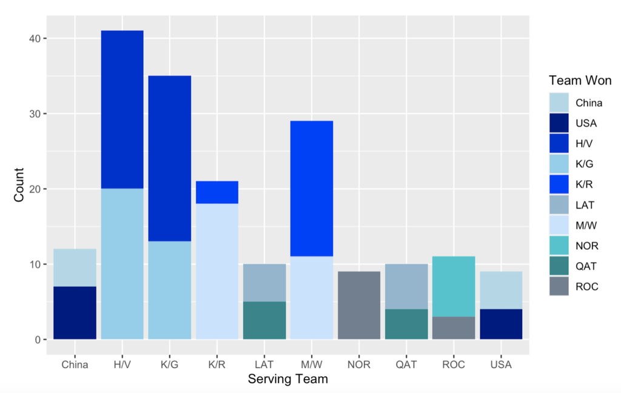

#### Figure 2:

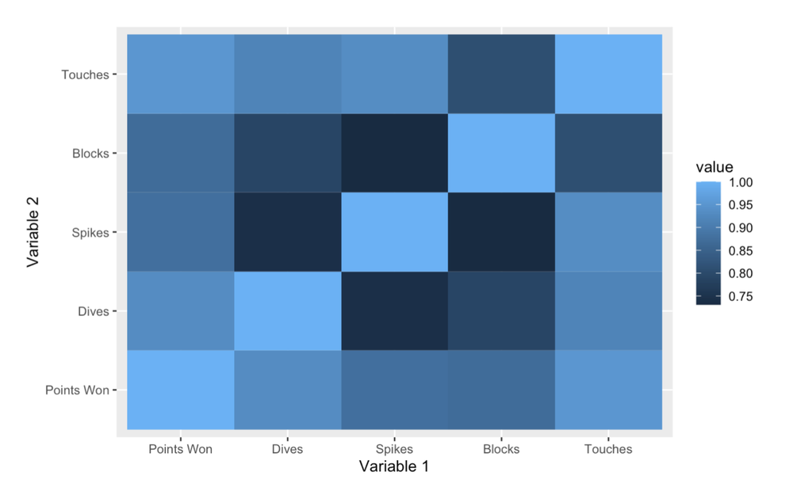

Figure 2 above illustrates the correlations between the various types of hits as well as total touches and total points won by a given team. All three of the types of hits observed (blocks, spikes, and dives) were shown to have a high positive correlation (each greater than 0.86) with the total number of points a team won, demonstrating that effective execution of both offensive and defensive hits is important to the overall success of a given point. Somewhat unexpectedly, the variable with the highest correlation (0.95) to total points scored was total touches. While we initially anticipated a high average number of touches to be indicative of an inability to effectively finish a point, it appears on the contrary to demonstrate an aptitude for keeping the ball in play for long enough to strike. The lowest two correlations in the bunch–indicated by the darkest blue–are those between spikes and dives (0.74) and spikes and blocks (0.73), which is interesting as it could indicate a discrepancy in how much focus players and teams give to training/practicing offensive vs. defensive play.

#### Illustration 1

Game

Team

Photo.P1

Name.P1

Point.P1

Photo.P2

Name.P2

Point.Distribution.P2

USA v. China W 2012 S-Final

Team USA

Misty May-Treanor

27%

Kerri Walsh-Jennings

73%

USA v. China W 2012 S-Final

Team China

Xue Chen

60%

Zhang Xi

40%

Norway v. ROC M 2021 Final

Team Norway

Anders Mol

67%

Christian Sorum

33%

Norway v. ROC M 2021 Final

Team ROC

Viacheslav Krasilnikov

55%

Oleg Stoyanovskiy

45%

USA v. USA W 2012 Final

Team USA

Misty May-Treanor

54%

Kerri Walsh-Jennings

46%

USA v. USA W 2012 Final

Team USA

April Ross

40%

Jennifer Kessy

60%

LAT v. QAT M 2021 Bronze

Team Latvia

Martins Plavins

50%

Edgars Tocs

50%

LAT v. QAT M 2021 Bronze

Team Qatar

Cherif Younousse

67%

Ahmed Tijan

33%

LAT v. SUI W 2021 Bronze

Team Latvia

Kravcenoka

32%

T. Graudina

68%

LAT v. SUI W 2021 Bronze

Team Switzerland

J Heidrich

52%

A.Verge-Depre

48%

This illustration demonstrated the distribution of players’ contribution towards the random sample of points we recorded in our data. We divided the games based on teams and further divided the team into two players and calculated the proportion of each team’s points that each player contributed.

##### Insights

###### a) Does Serving help a team in winning a point?

For our first insight, we tried learning if the serving team has a competitive advantage and ends up winning the point out of the random points out of the whole match. Out of the 187 total points in our data, we observed that the serving team won the point only 69 times, which is 37% of the time. For that we created a table (3) and figure (1) that shows the number of times the team served and ended up winning a point. In order to gain a better understanding we also undertook a hypothesis test :

*Null Hypothesis (H0) = Serving team wins the point*

*Alternative hypothesis (Ha) = Serving team does not win the point*

Since both of these variables were categorical, we tried to do a chi squared test which evaluates whether there is a significant association between the categories of the two variables.

*test1 <- chisq.test(data$Serving.team,data$Team.won)* *test1$observed*

An interesting thing we learned from this insight was that serving does not give the team a competitive advantage of winning a point. The team that wins the point gets to serve, so it’s interesting to see that the serving team is less likely to win the point. Another interesting thing that we learned was that the serves constantly switched between teams rather than one team serving for most of the game. This makes sense from our insight of teams less likely to win the point when serving. The highest serving streak we saw was 4 serves until the team lost the point and the serve switched to the other team. On average, a team served 1.2 times before the serve switched to the other team.

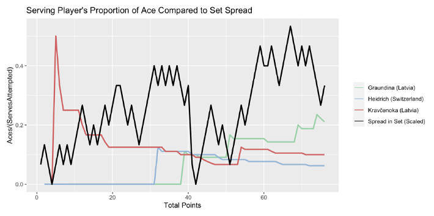

Proportion of ace throughout the female Switzerland vs. Latvia bronze medal Olympic match (2021). Spread in Set: abs(Points_Switzerland - Points_Latvia)/c, with c = 15. The reversion in spread back to 0 at 42 points represents a change in sets. Aces/(Serves Attempted): proportion of serves that were aces at the current point for each player. Vergé-Dépré (Switzerland) did not score any aces and is absent from the figure.

Given the high likelihood of losing the point when serving, there is a large incentive to score an ace without having to risk the opposing team returning the ball. 36.4% (68/187) of the serves in our dataset resulted in the opposing team immediately scoring with a spike using 3 or fewer touches (bump, set, spike) before the serving team could return the ball.

#Find probability (Opposing team (Non-Serving) has 3 or fewer touches and scores with a spike) = 68/187. Or, the likelihood your serve is returned with a winning spike by the opposing team.

###### b) Distribution of players within a team and their closing moves

For our next insight, we examined if teamwork played a role in winning the match by seeing if the team with both teammates contributing close to equal number of points tended to win. We hypothesized that the team that had both players contributing an equal number of points would win the match. For this, we collected the points scored by individual players in our random data set and calculated the probability based on the number of points we recorded for that team which can be seen in Illustration 1.

We then compared the individual points of the players during the actual game and formed a hypothesis:

*H0 = Teammates contribute equal number of points and leading them to win*

Finally, when it comes to what we could have done better, we feel like instead of analyzing random points of various games, we could have compared values for 2 full games at the same level like Finals of Olympics etc. We could have cleaned our data more in order to avoid two different spellings for a particular term like spike and spikes. We could have also chosen a set of different variables for the game like Rally time, set time, match time, serve efficacy (standing serve, floating serve, and jump serve), setting efficacy (forearm, overhand, other, and 2nd attack), attack efficacy, and block efficacy. These could have been a perfect mix of categorical and numerical variables and would have helped us to understand the game and come up with better insights. We would have also made some minor aesthetic changes to the paper such as un-stretching the player images in the chart.

##### Sources:

https://olympics.com/tokyo-2020/en/replay/